# Asociacion de variables mediante análisis de regresión generalizado y análisis factorial multivariante

David Palomino Plantón

2026-05-24

# Inserción y procesado de los datos

En primer lugar, introduciremos en R los dos dataframes que hemos creado con los datos de SAA junto con los datos clínicos, geneticos y demográficos para 24h/150h

```r
library(readr)
library(FactoMineR)
library(factoextra)
```

```r
library(ggplot2)
library(patchwork)
library(logistf)
library(dplyr)
library(ggforce)
library(missMDA)
library(ggrepel)   # etiquetas sin flechas en gráficos de variables cualitativas
library(corrplot)  # matriz de correlación
library(tidyr)     # pivot_longer para la matriz de correlación
plot_contrib_es <- function(res, axes = 1, titulo = NULL, top = 6) {
  p <- fviz_contrib(
    res,
    choice = "var",
    axes = axes,
    top = top
  )

  # Quedarse solo con las top variables ya filtradas por fviz_contrib
  dat <- p$data
  dat <- dat[order(dat$contrib, decreasing = TRUE)[seq_len(min(top, nrow(dat)))], ]
  dat$etiqueta <- paste0(round(dat$contrib, 1), "%")

  p +
    geom_text(
      data = dat,
      aes(label = etiqueta),
      vjust = -0.4,
      size = 2.8,
      color = "gray20"
    ) +
    scale_y_continuous(
      expand = expansion(mult = c(0, 0.22))
    ) +
    theme(
      axis.text.x  = element_text(size = 8.5, angle = 40, hjust = 1,
                                  color = "gray10", face = "bold"),
      axis.text.y  = element_text(size = 8,   color = "gray20"),
      axis.title   = element_text(size = 9,   color = "gray10"),
      plot.title   = element_text(size = 10,  face = "bold", hjust = 0.5,
                                  color = "gray10"),
      panel.grid.minor = element_blank()
    ) +
    labs(
      title = titulo,
      x = NULL,
      y = "Contribución (%)"
    )
}

# ─────────────────────────────────────────────────────────────────────────────
# Función: gráfico de categorías cualitativas coloreado por variable con leyenda
# Sustituye únicamente a fviz_famd_var(..., "quali.var", col.var = "contrib/cos2")
# El resto del código (scree plots, fviz_contrib, etc.) no se toca
# ─────────────────────────────────────────────────────────────────────────────
obtener_quali_coords_famd <- function(res.famd) {
  quali_coords <- as.data.frame(res.famd$quali.var$coord[, 1:2])
  colnames(quali_coords) <- c("Dim1", "Dim2")
  quali_coords$categoria_original <- rownames(quali_coords)

  var_info <- res.famd$call$X
  factor_vars <- names(var_info)[sapply(var_info, is.factor)]

  mapa_categorias <- data.frame(
    variable = rep(factor_vars, times = sapply(var_info[factor_vars], nlevels)),
    categoria_limpia = unlist(lapply(var_info[factor_vars], levels), use.names = FALSE),
    stringsAsFactors = FALSE
  )

  mapa_categorias$categoria_original <- make.unique(mapa_categorias$categoria_limpia)

  quali_coords %>%
    left_join(mapa_categorias, by = "categoria_original") %>%
    mutate(
      variable = ifelse(is.na(variable), "Variable no identificada", variable),
      categoria_limpia = ifelse(is.na(categoria_limpia), categoria_original, categoria_limpia),
      categoria = paste0(variable, ": ", categoria_limpia)
    )
}

plot_quali_by_var <- function(res.famd, titulo = "") {
  coords <- obtener_quali_coords_famd(res.famd)
  n_vars <- length(unique(na.omit(coords$variable)))

  ggplot(coords, aes(x = Dim1, y = Dim2, color = variable, label = categoria)) +
    geom_point(size = 3, alpha = 0.8) +
    ggrepel::geom_text_repel(
      size          = 3.5,
      max.overlaps  = 20,
      segment.size = 0.3,
      segment.color = "gray60"
    ) +
    geom_hline(yintercept = 0, linetype = "dashed", color = "gray50") +
    geom_vline(xintercept = 0, linetype = "dashed", color = "gray50") +
    scale_color_manual(
      values   = scales::hue_pal()(n_vars),
      name     = "Variable",
      na.value = "gray70"
    ) +
    labs(
      title = titulo,
      x     = paste0("Dim1 (", round(res.famd$eig[1, 2], 1), "%)"),
      y     = paste0("Dim2 (", round(res.famd$eig[2, 2], 1), "%)")
    ) +
    theme_minimal() +
    theme(legend.position = "right")
}

# Función auxiliar para localizar los CSV traducidos al español.
# Busca primero en el directorio de trabajo, después junto al Rmd y, por último, en /mnt/data.
# Acepta varios nombres alternativos para que funcione también con los archivos descargados como "(1)".
ruta_csv <- function(nombres) {
  input_rmd <- tryCatch(knitr::current_input(dir = TRUE), error = function(e) NULL)

  for (nombre in nombres) {
    if (file.exists(nombre)) return(nombre)

    if (!is.null(input_rmd)) {
      ruta_rmd <- file.path(dirname(input_rmd), nombre)
      if (file.exists(ruta_rmd)) return(ruta_rmd)
    }

    ruta_mnt <- file.path("/mnt/data", nombre)
    if (file.exists(ruta_mnt)) return(ruta_mnt)
  }

  stop(paste(
    "No se encuentra ninguno de estos archivos:",
    paste(nombres, collapse = ", "),
    "Coloca el CSV en el directorio de trabajo o junto a este Rmd."
  ))
}

df_150 = read_csv("C:/Users/david/Desktop/master/TFM/CSV/df_150_score_imputado_ES.csv")
df_24 = read_csv("C:/Users/david/Desktop/master/TFM/CSV/df_24_score_imputado_ES.csv")
#df_24 <- na.omit(df_24)
#df_150 <- na.omit(df_150)
```

Especificamos cuales son las variables nominales en nuestros datos

```r
vars_nominales <- c(
  "grupo de estudio",
  "sexo",
  "raza",
  "etnia",
  "mutación GBA",
  "mutación LRRK2",
  "mutación SNCA",
  "mutación APOE_E4",
  "mutación EP"
)
```

```r
#Eliminamos las variables que no nos son de ninguna utilidad una vez rehecha la variable grupo de edad

df_24 <- df_24[, -c(1,2,3,4,5)]
df_150 <- df_150[, -c(1,2,3,4,5)]
```

Ahora lo representamos mediante un gráfico de barras para ver la representación visual de la distribución de edad de los distintos pacientes en nuestros datos

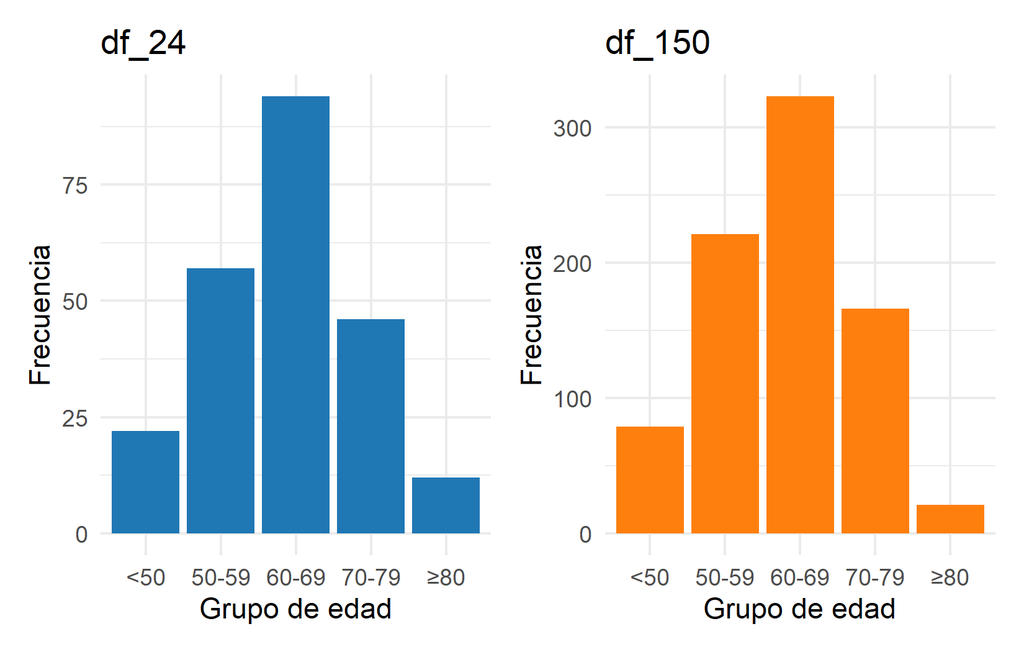

```r
orden <- c("<50", "50-59", "60-69", "70-79", "≥80")

df_24$`grupo de edad` <- factor(df_24$`grupo de edad`, levels = orden)
df_150$`grupo de edad` <- factor(df_150$`grupo de edad`, levels = orden)

p1 <- ggplot(df_24, aes(x = `grupo de edad`)) +
  geom_bar(fill = "#1f77b4") +  # azul
  ggtitle("df_24") +
  xlab("Grupo de edad") +
  ylab("Frecuencia") +
  theme_minimal()

p2 <- ggplot(df_150, aes(x = `grupo de edad`)) +
  geom_bar(fill = "#ff7f0e") +  # naranja
  ggtitle("df_150") +
  xlab("Grupo de edad") +
  ylab("Frecuencia") +
  theme_minimal()

p1 + p2
```

Ahora convertiremos la variable estado SAA en factor debido a que es nuestra variable respuesta.

```r
df_150$Y <- df_150$`estado SAA`
df_150$`estado SAA` <- NULL
df_24$Y <- df_24$`estado SAA`
df_24$`estado SAA` <- NULL
```

# Análisis de regresión generalizada

Pasamos las variables cualitativas a factor.

```r
df_150 <- df_150 %>%
  mutate(across(where(is.character), as.factor))

df_24 <- df_24 %>%
  mutate(across(where(is.character), as.factor))
```

Ejecutamos el análisis de regresión generalizada:

150h:

```r
modelo_glm150 <- glm(
  Y ~ .,
  family = binomial,
  data = df_150
)

summary(modelo_glm150)
```

```
##
## Call:
## glm(formula = Y ~ ., family = binomial, data = df_150)
##
## Coefficients:
##                                                  Estimate Std. Error z value
## (Intercept)                                      -1.99204 2560.11209  -0.001
## `grupo de edad`50-59                             -0.31647    0.52939  -0.598
## `grupo de edad`60-69                             -0.25852    0.51632  -0.501
## `grupo de edad`70-79                             -0.55778    0.55567  -1.004
## `grupo de edad`≥80                               -2.06933    0.77937  -2.655
## sexoMujer                                        -0.47220    0.26107  -1.809
## etniaHispano o latino                            14.95425 2399.54480   0.006
## etniaNo hispano o latino                         14.77190 2399.54476   0.006
## razaBlanca                                      -14.06897  892.38791  -0.016
## razaDesconocida                                 -12.92317  892.39051  -0.014
## razaMultirracial                                -13.68708  892.38825  -0.015
## razaNegra o afroamericana                       -14.80510  892.38840  -0.017
## razaOtra                                        -12.18516  892.38918  -0.014
## `grupo de estudio`Cohorte genética no afectada   -4.17705    0.67645  -6.175
## `grupo de estudio`Control sano                   -4.05634    1.05180  -3.857
## `grupo de estudio`EP                              2.14046    0.95188   2.249
## `grupo de estudio`Prodrómico                      1.37704    1.14224   1.206
## `mutación GBA`Sí                                  1.36000    0.88593   1.535
## `mutación LRRK2`Sí                                0.03882    0.97673   0.040
## `mutación SNCA`Sí                                 1.93819    1.33178   1.455
## `mutación APOE_E4`Sí                             -0.26111    0.46005  -0.568
## `mutación EP`Sí                                   0.68576    0.62390   1.099
## `valor MDS UPDRS III`                             0.01833    0.02070   0.886
## `Estadío Hoehn & Yahr`                           -0.39486    0.34658  -1.139
## `valor MoCA`                                      0.08662    0.04569   1.896
##                                                Pr(>|z|)
## (Intercept)                                    0.999379
## `grupo de edad`50-59                           0.549972
## `grupo de edad`60-69                           0.616583
## `grupo de edad`70-79                           0.315474
## `grupo de edad`≥80                             0.007927 **
## sexoMujer                                      0.070499 .
## etniaHispano o latino                          0.995028
## etniaNo hispano o latino                       0.995088
```

[output cut: 12 more lines]

```
## `mutación APOE_E4`Sí                           0.570327
## `mutación EP`Sí                                0.271702
## `valor MDS UPDRS III`                          0.375872
## `Estadío Hoehn & Yahr`                         0.254583
## `valor MoCA`                                   0.058023 .
## ---
## Signif. codes:  0 '***' 0.001 '**' 0.01 '*' 0.05 '.' 0.1 ' ' 1
##
## (Dispersion parameter for binomial family taken to be 1)
##
##     Null deviance: 1097.16  on 809  degrees of freedom
## Residual deviance:  453.99  on 785  degrees of freedom
## AIC: 503.99
##
## Number of Fisher Scoring iterations: 15
```

24h:

```r
modelo_glm24 <- glm(
  Y ~ .,
  family = binomial,
  data = df_24
)

summary(modelo_glm24)
```

```
##
## Call:
## glm(formula = Y ~ ., family = binomial, data = df_24)
##
## Coefficients:
##                                                  Estimate Std. Error z value
## (Intercept)                                      -1.76962    3.12205  -0.567
## `grupo de edad`50-59                             -1.63500    0.81470  -2.007
## `grupo de edad`60-69                             -1.22543    0.81648  -1.501
## `grupo de edad`70-79                             -1.51096    0.86851  -1.740
## `grupo de edad`≥80                               -3.64452    1.10935  -3.285
## sexoMujer                                        -0.62357    0.37952  -1.643
## etniaNo hispano o latino                          0.42245    0.50896   0.830
## razaBlanca                                       -0.21711    2.32265  -0.093
## razaDesconocida                                  13.16398 1348.79401   0.010
## razaMultirracial                                 -0.58535    2.41114  -0.243
## razaNegra o afroamericana                       -19.89565 2399.54595  -0.008
## razaOtra                                         -1.49352    2.97792  -0.502
## `grupo de estudio`Cohorte genética no afectada   -0.66163    0.90194  -0.734
## `grupo de estudio`Control sano                   -2.31612    1.24421  -1.862
## `grupo de estudio`EP                              1.07481    0.73696   1.458
## `grupo de estudio`Prodrómico                      2.48027    1.19822   2.070
## `mutación GBA`Sí                                 -0.11420    0.64207  -0.178
## `mutación LRRK2`Sí                               -1.10040    0.73838  -1.490
## `mutación SNCA`Sí                                15.39724 2399.54496   0.006
## `mutación APOE_E4`Sí                             -0.30243    0.53994  -0.560
## `mutación EP`Sí                                   0.90243    0.74822   1.206
## `valor MDS UPDRS III`                             0.01848    0.03325   0.556
## `Estadío Hoehn & Yahr`                           -0.12032    0.47818  -0.252
## `valor MoCA`                                      0.12537    0.06270   1.999
##                                                Pr(>|z|)
## (Intercept)                                     0.57084
## `grupo de edad`50-59                            0.04476 *
## `grupo de edad`60-69                            0.13339
## `grupo de edad`70-79                            0.08191 .
## `grupo de edad`≥80                              0.00102 **
## sexoMujer                                       0.10037
## etniaNo hispano o latino                        0.40653
## razaBlanca                                      0.92553
## razaDesconocida                                 0.99221
```

[output cut: 10 more lines]

```
## `mutación APOE_E4`Sí                            0.57540
## `mutación EP`Sí                                 0.22778
## `valor MDS UPDRS III`                           0.57841
## `Estadío Hoehn & Yahr`                          0.80134
## `valor MoCA`                                    0.04556 *
## ---
## Signif. codes:  0 '***' 0.001 '**' 0.01 '*' 0.05 '.' 0.1 ' ' 1
##
## (Dispersion parameter for binomial family taken to be 1)
##
##     Null deviance: 309.76  on 230  degrees of freedom
## Residual deviance: 202.18  on 207  degrees of freedom
## AIC: 250.18
##
## Number of Fisher Scoring iterations: 15
```